# Getting started with eco-evo model

I have never used R Notebooks before, nor have I ever built a model for publication. Let’s try it!

The goal here is to sketch out the main ideas that I have for the eco-evolutionary model that Holly and I proposed as a part of my NSF postdoc application.

Here is what I proposed to do:

“I will examine how trees shift their portfolio strategies under simulated drought scenarios of varying frequency, intensity, and duration. In this stage-structured model, individual trees will be assigned fungal portfolio strategies. These strategies will be defined by two primary traits: the number of fungi a tree associates with (q) [this was theta originally, but copy-paste made it q, which is fine with me], a measure of specificity, and the degree to which those fungi improve tree performance, on average, in the current environment (s) [originally sigma]. Both of these traits will influence the demographic rates of the trees and their reproductive outputs. New portfolio strategies will emerge occasionally via mutation. I will use this model to explore the adaptive dynamics of this tree-fungal mutualism, identifying optimal portfolio strategies under each environment, and determining which may represent evolutionarily stable strategies for trees”

So. To make this happen I will need a population of trees. This population has a couple of key properties:

A distribution of q values (from low specificity to high specificity)

A distribution of s values in environment A (from low benefit to high benefit)

A distribution of s values in environment B (from low to high benefit)

I will also eventually need a “population” of drought scenarios. These will vary in

frequency

intensity

duration

With some reasonable probabilities associated with each state.

I’ll start with the trees to try to get a simulated population going. Then I will try two environmental conditions. Then I’ll see if I can get the populations to evolve via simulation. Only THEN will I layer in more nuanced drought scenarios.

Each tree has a q value and an s value.

We’re going to have a forest of 100 trees.

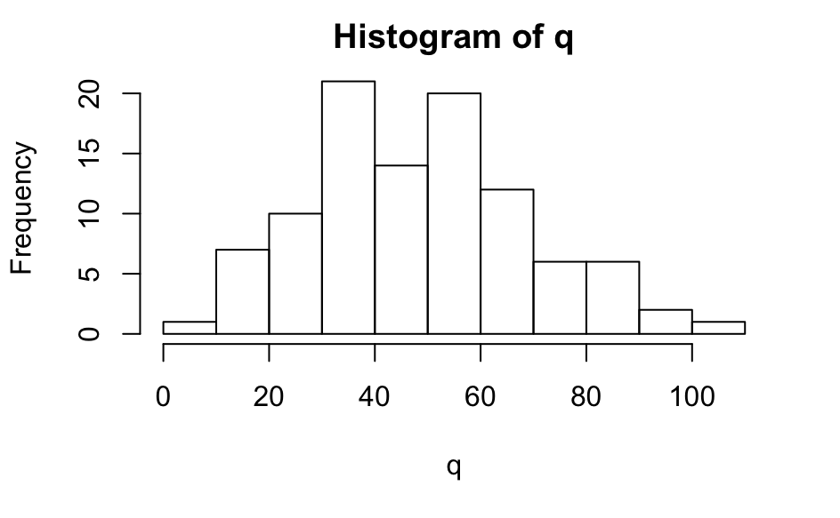

Are all these fungi equally useful? Probably not. Let’s treat the benefit axis (s) as a growth response for now, so it lines up well with empirical results. A growth response is:

mass of tree with fungi/mean mass of trees without fungi

Conveniently, if you take the natural log, this metric produces negative values when a fungus is parasitic, and positive values when the fungus is helpful. (I don’t know if this will prove unwieldy in a modeling context. Let’s see how it goes. We’ll start with the basic ratio and then log-transform if possible/appropriate)

In realistic circumstances, it would be surprising if a fungus reduced a plant’s growth by more than 50% without just killing it. (Perhaps I should work in a “the plant died” option down the line.) And the greatest growth IMPROVEMENT I’ve ever seen in a seedling was 5X, with Arbutus menziesii seedligs and Thelephora terrestris in a very low-N artificial soil after about a year of growth. (Note: Eventually I should tie these values to a lit review. But, for now, we’re building this model based on my instincts.)

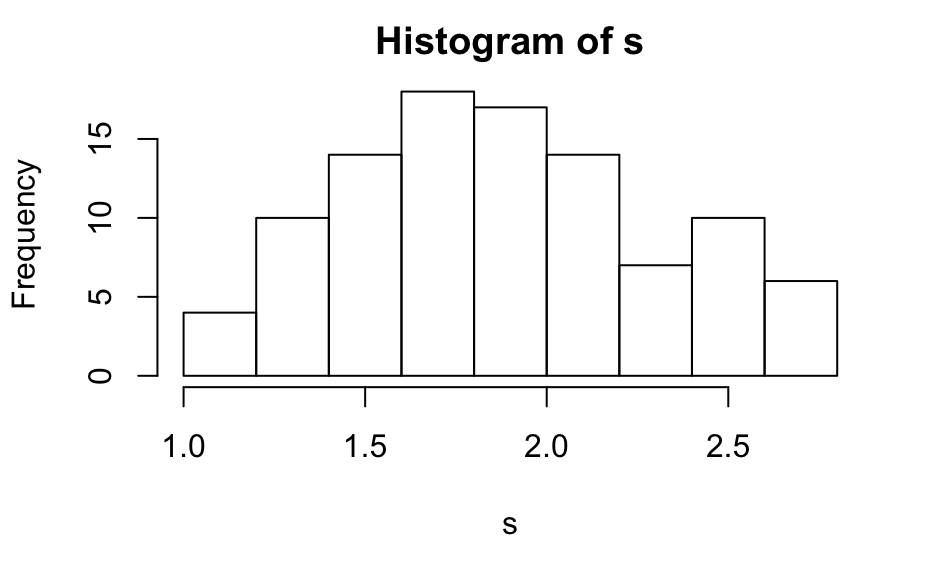

Now I need to actually make the trees by giving each tree a set of traits (q,s), and somehow evolve them. q and s aren’t sorted – might as well just treat the first entry as tree 1, the second entry as tree 2, etc.

How should this work? Each tree will basically clone itself. The probability of reproduction and/or number of offspring should be a function of s (benefit).

But wait – should s be a property of EACH fungus? It should. So I guess each tree should pull a number of values from s depending on how many fungi it has?

We need some kind of permanent (or at least durable) link between s ( the benefit provided by a fungus) and the identity of a fungus through time, if I’m going to see any trees evolve to specialize on particular fungi.

Hmmmmm

Okay. What if each tree, t(i), grabs q values from the s distribution, then takes as its benefit the mean of all those values?

```r
portfolios
```

[output not shown]

[output cut: 1145 more lines]

All right, it worked! Each tree now has a portfolio of fungi defined by the benefit they provide.

In order to evolve this population, I need these values to correspond to survival and reproductive probabilities.

For the moment, let’s simplify everything and say that, if a tree gets less benefit than average, it doesn’t survive to the next time step.

Questions that come to mind here: - Should the trees be competing with each other to determine survival/repro? What function should I be using?

```r
average_benefit
```

```
[1] 1.875277
```

All right! So, I have manually walked through a whole time step.

This seems like a good place to start. Tomorrow, I’d like to: 1) Put this material into a loop that spits out summary statistics (distribution of portfolio benefits at each time step, for example) as we go along, 2) Make some kind of graphic illustrating upward creep of portfolio benefit through time, 3) discern whether q (number of partners) is creeping up or down over time.